# Some MonteCarlo simulations

*Yimi J. Perla*

yjperla@hotmail.com

## Abstract

Here, different simulations using MonteCarlo methods are presented. First, a linear fitting of random points is done several times, the fitted slope is found to follow a normal distribution. Then, these points are made to change in each iteration, so the fitted slope at the end does not show a normal distribution. The fitting is also done for three clouds of random points, with similar results to the first one. Another problem studied through MonteCarlo methods is how two non overlapping disks can be randomly distributed in a square. Also, a simulation in which distances between random points in two disks are used to get the distance between the centers is done. Finally, two non overlapping disks confined in a square are generated, but this time the disks move using a Metropolis algorithm in which the most probable position is at the center of the square, following a normal distribution.

## 1. Introduction

A given problem can be solved through random sampling. The simulations proposed here explore this way of solving problems, in no way this is intended as the most efficient method of solving these problems but is only done to illustrate MonteCarlo methods.

## 1.1 MonteCarlo

A MonteCarlo method consists in the use of random numbers to solve a problem, this is done by repetitive simulation.

## 1.2 Metropolis algorithm

The Metropolis algorithm is a MonteCarlo method which consists on iterations which seeks an equilibrium statistical solution in the following manner:

- We starty any allowed point $\textbf{r}$, so-called *walker*.
- We “shake” the point, get a new oner $\textbf{r}' = \textbf{r} + \delta$ where $\delta$ is a vector such that each of its components is a uniform random number in $[-a,a]$. This is calle "random walk".
- Evaluate $q=p(\textbf{r}')/ p(\textbf{r})$, the ratio of probabilities of new and original position.
- Accept or reject $\textbf{r}'$ by choosing a random number $t$ between 0 and 1. If t<q the new position is $\textbf{r}'$, otherwise, we keep the old position.
- It eventually converges to a desired probability distribution.

## 2. Simulations

## 2.1 Linear fitting

Random numbers with normal distribution are generated around three positions $x=-1, x=0, x=1$, then another set of random points with normal distribution are generated whose mean is each number in the first set, this will be used as coordinates on the $y$ axis on the plane. With this we seek a $y=x$ like function, so the fitting should give a slope equal to 1. The result of fitting one time can be seen on figure 1:

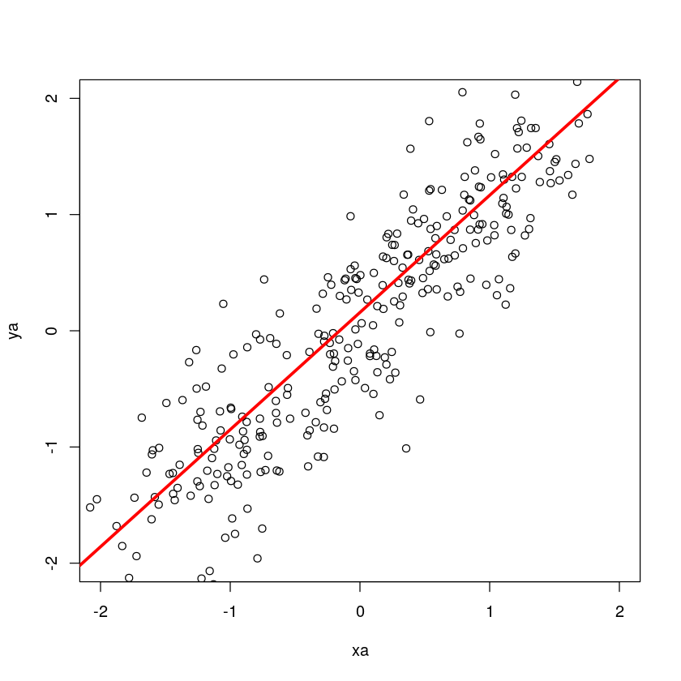

Figure 1: Linear fitting of random points.

In this particular figure, the slope is 1.0083. Since the numbers are randomly generated, each time the slope will be different. By repeating this process 1000 times, the slope was found to follow a symmetric distribution with mean 0.9976 as shown in figure 2, this adjusts very well to a normal distribution with same mean(red line):

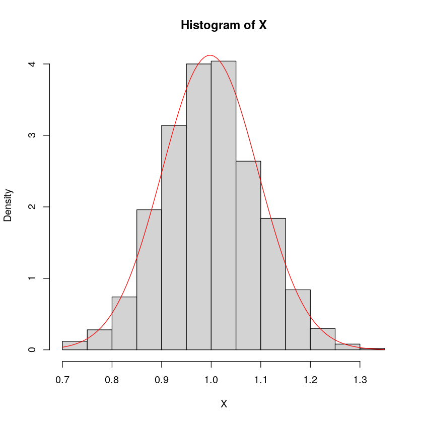

Figure 2: Histogram of the slope calculated 1000 times for a set of random points. In red we have a normal distribution with same mean.

## 2.1.2 Linear fitted slope with non normal distribution

The normal distribution obtained in figure 2 should not depend on the fact that the randomly generated points are gaussian, we would get the same kind of distribution if we generate the random numbers following another distribution but in a consistent way on each iteration.

We can nevertheless obtain a slope which follow another distribution if the shape of the plot were to change on each step.

For steps going from i=1 to i=1000, if we multiply the y position by i/1000, the histogram for the slope will be:

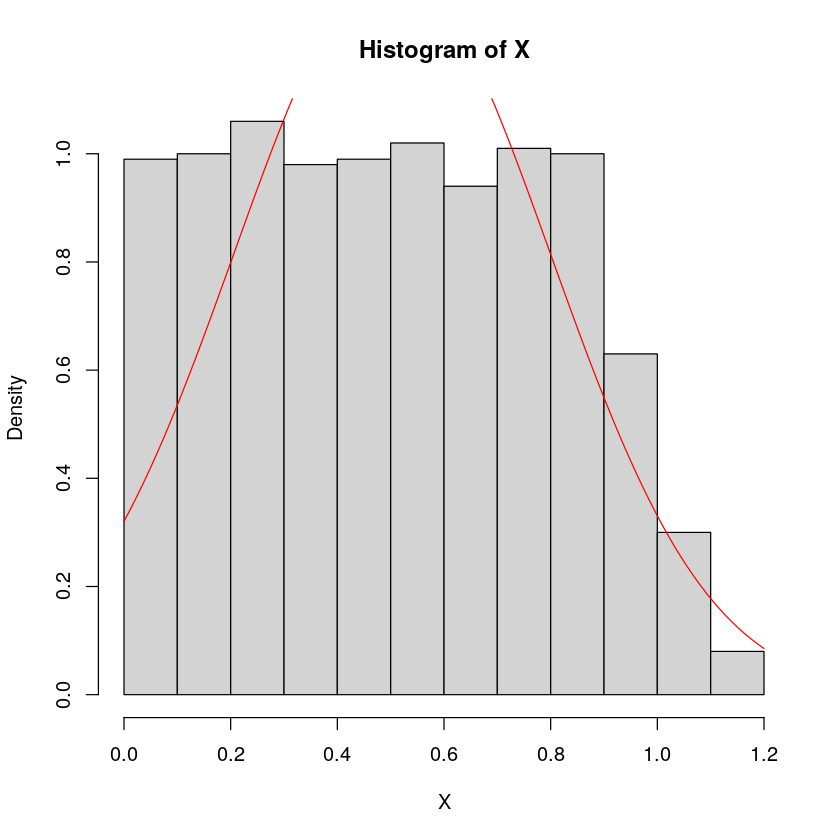

Figure 3: Histogram of the slope calculated 1000 times for a set of random points. The y position changes with i iterations as i/1000.

Here, the mean is 0.5027 but this is because it changes with each step.

Is possible to get many shapes doing this. Another example would be to leave the position at $x=0, y=0$ untouched but multiply the other extremes by $sin^2 i$. The histogram for this case (with mean 0.6687) is:

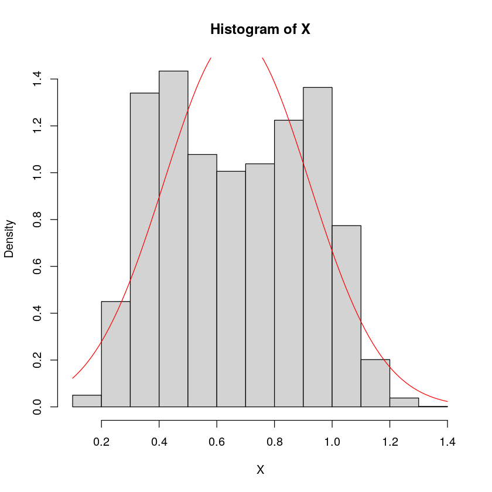

## 2.2 Linear fitting for clouds of points

This time, the random points are generated through a slighty different method. Three sets of random numbers $xa, xb, xc$ are generated following a normal distribution with means $1-, 0, 1$ respectively. In the same manner, another set $ya, yb, yc$ is generated. The means were arbitrarily choosen so we have another $y=x$ like function for the centers of the clouds. After fitting one time, the result is:

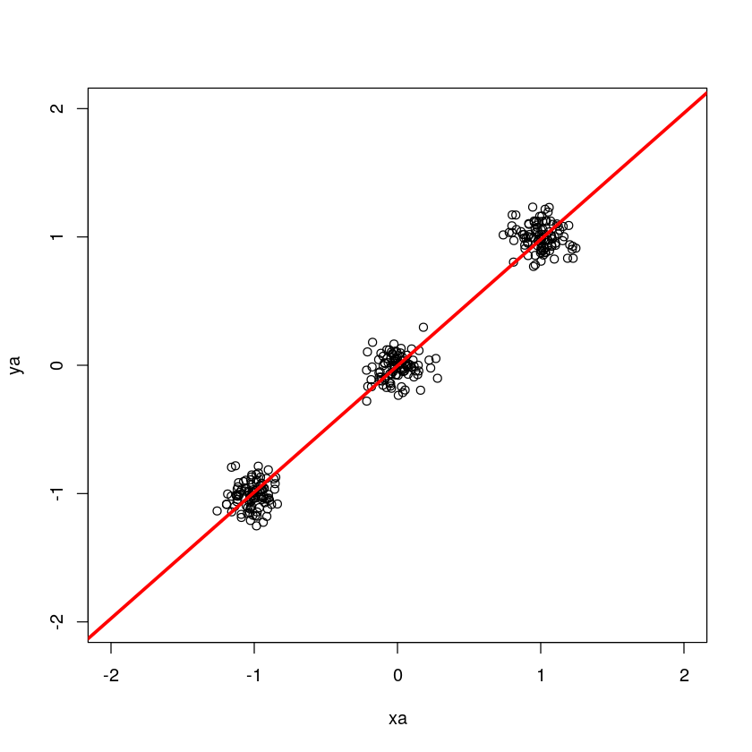

Figure 5: Linear fitting for clouds of random points.

The wanted slope is 1 and for the one time fitting shown above, the slope is 0.9846. The points are generated in a different manner but the problem of looking for the slope by a MonteCarlo method is equivalent to the first simulation described in section 2.1. Ase seen in figure 6, the histogram after 1000 steps adjusts very well to a normal distribution (red curve):

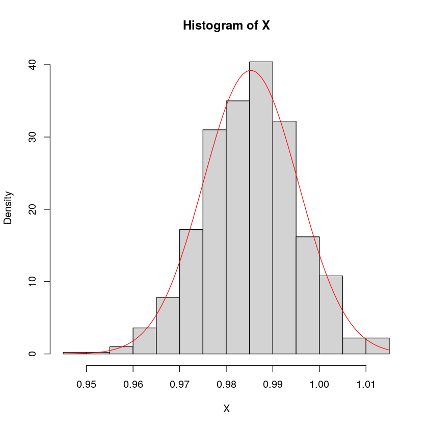

Figure 6: Histogram of the slope calculated 1000 times for clouds of random points. In red we have a normal distribution with same mean.

The mean of the slope after calculating 1000 times is 0.9853.

## 2.3 Distribution of two disks inside a square

Consider two disks of radii R inside a side L square. Let us introduce two conditions for these disks:

- A disk can not go outside the square.
- The disks can not overlap.

A MonteCarlo simulation is done by randomly generating these two disks 1000 times and looking at the distribution of their possible positions. In Figure 7 the positions of the centers of the disks in a square of side L=1 is shown for different radii:

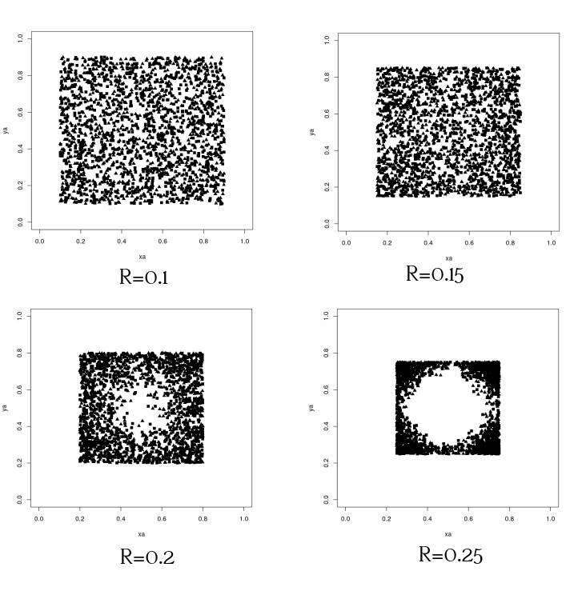

Figure 7: Positions of the centers of two randomly generated disks inside a square of side L, for different radii.

The histograms for positions (xa, ya) of diks A, and positions (xb, yb) of disk B for different radii is shown in Figure 8:

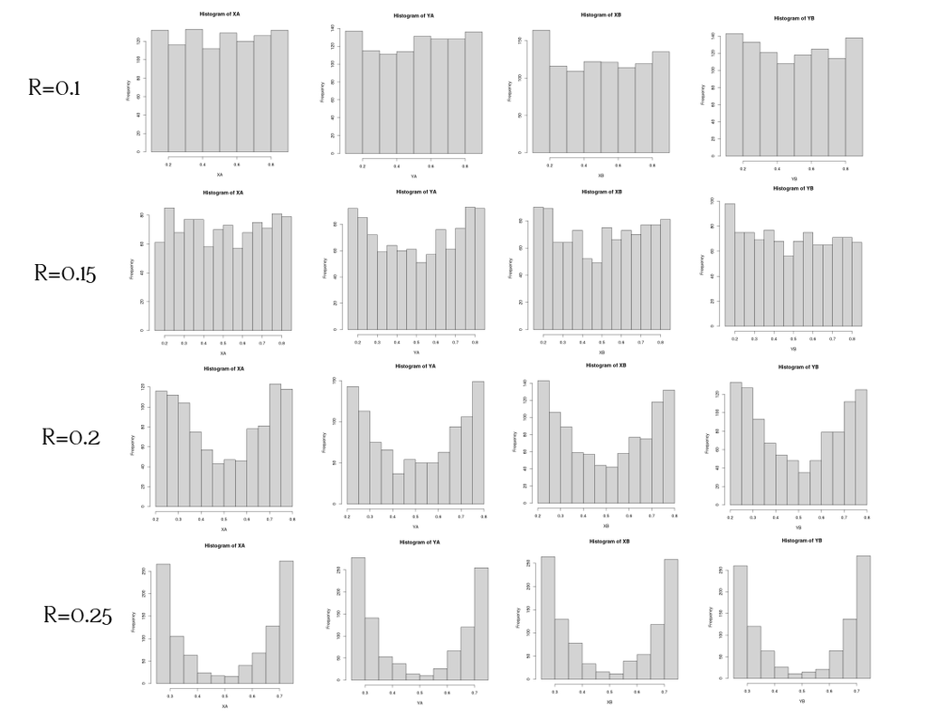

Figure 7: Histograms of rectangular coordinates for the randomly generated disks.

## 2.4 Distance between the center of two disks

Let us assume we can find the distance between the center of two disks by measuring distances between random points contained in the disks. This is evidently wrong if both centers are in the same position, because the distance should be zero but by this method we always will get a non-zero result. The case of two very far away disks is also of no interest because then the diks could be considered points and the result would clearly be approximately correct.

In this simulation sets of 1000 random points contained inside two diks of radii 1 are generated. One disk has center at (0,0) and the other has it's center at (1.5,1.5) as shown inf Figure 8:

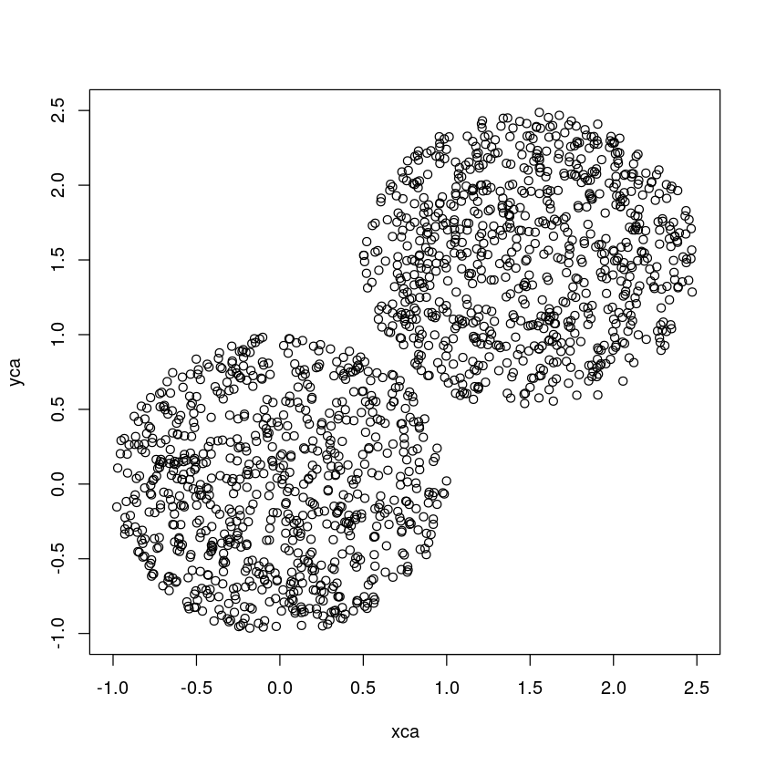

Figure 8: One disk at (0,0) and another at (1.5,1.5). 1000 random points contained in each.

The distance between both centers is then 2.1213, that is, 1.0607 times the diameter of the disks. It would then be interesting if the assumption described above holds and we get an answer close to the distance between the centers.

After generating and measuring distances between two random points, one in each disk, 10000 times, we get the histogram shown in figure 9 which fits very well to a normal distribution (red line).

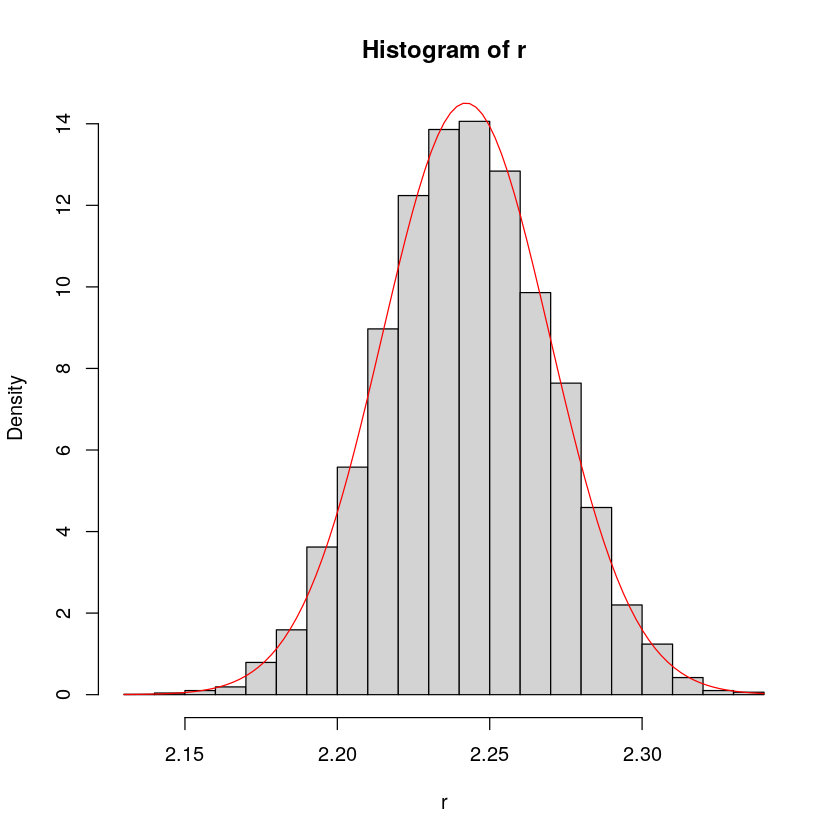

Figure 9: Histograms of distances between random points in the disks.

The mean obtained is 2.2422 which compared to the expected distance 2.1213 gives a 5.70% error.

## 2.5 Movement of two diks inside a square using a Metropolis algorithm

Figure 10 shows the result of repeating this 1000 times:

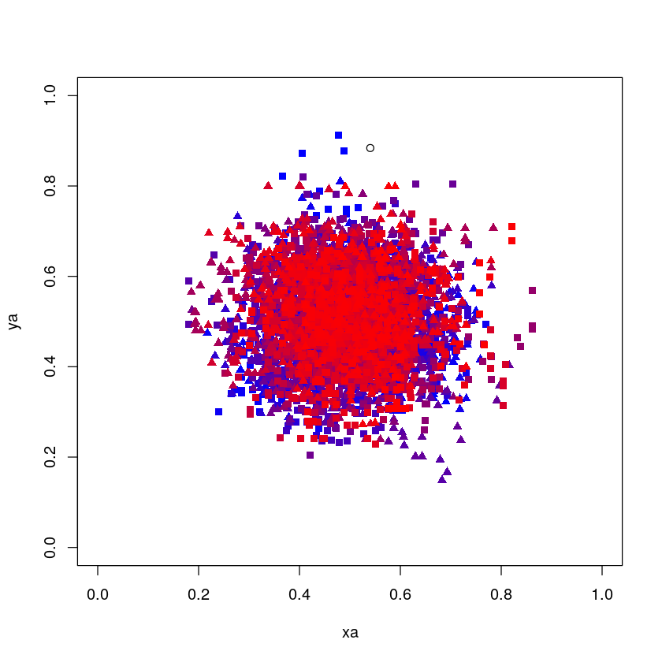

Figure 10: Positions of the centers of two disks in a square. The triangles represents disk A and the squares circle B. The points gradually change from blue to red with each iteration. The probability distribution is choosen so that both disks try to reach the center of the square.

Histograms of the rectangular coordinates for both disks is shown in figure 11:

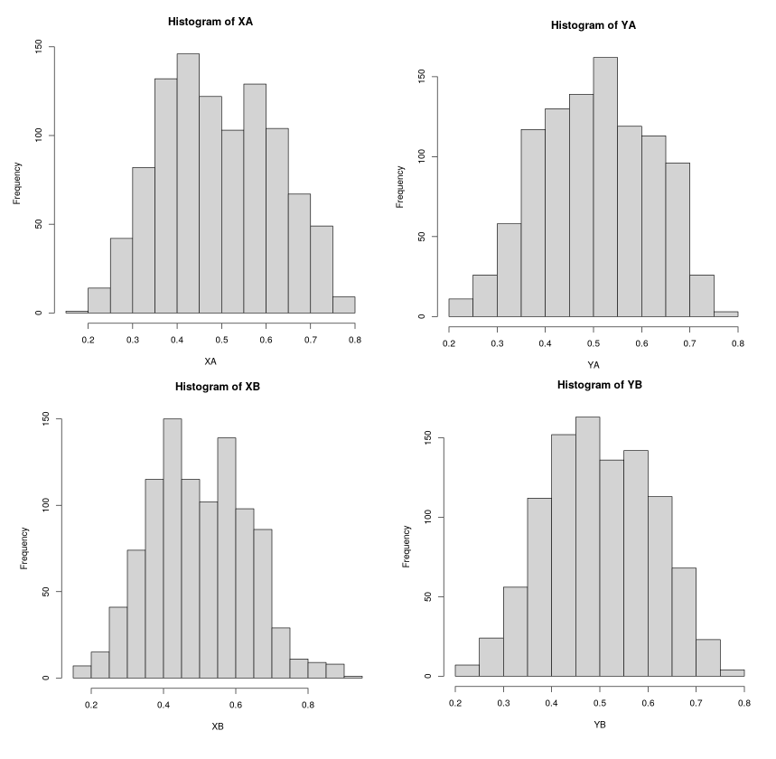

Figure 11: Histograms of rectangular coordinates for disks A and B.

## 3. Conclusions

The simulations presented here used random sampling to get results. If each iteration in a simulation uses a different set of random points, then the results differ but if the method of random generation of data is consistent, then the results do vary following a symmetric distribution, as seen in most of the histograms, presented this is usually a Gaussian distribution. If the sampling changes with time, then a non-normal distribution can be obtained, even a non-symmetric one as in Figure 3.

These simulations also illustrate how a MonteCarlo method can succesfully give approximate results to a given problem.

## 4. References

- Anderson, Herbert L. (1986). "Metropolis, Monte Carlo and the MANIAC" (PDF). Los Alamos Science. 14: 96–108.
- Hastings, W.K. (1970). "Monte Carlo Sampling Methods Using Markov Chains and Their Applications". Biometrika. 57 (1): 97–109. Bibcode:1970Bimka..57...97H. doi:10.1093/biomet/57.1.97. JSTOR 2334940. Zbl 0219.65008.
- Nicholas T. Thomopoulos; Essentials of Monte Carlo Simulation: Statistical Methods for Building Simulation Models.

Software:

R Core Team (2019). R: A language and environment for statistical computing. R Foundation for Statistical Computing, Vienna, Austria. URL https://www.R-project.org/.

```
    x_fit
0.8971947
```

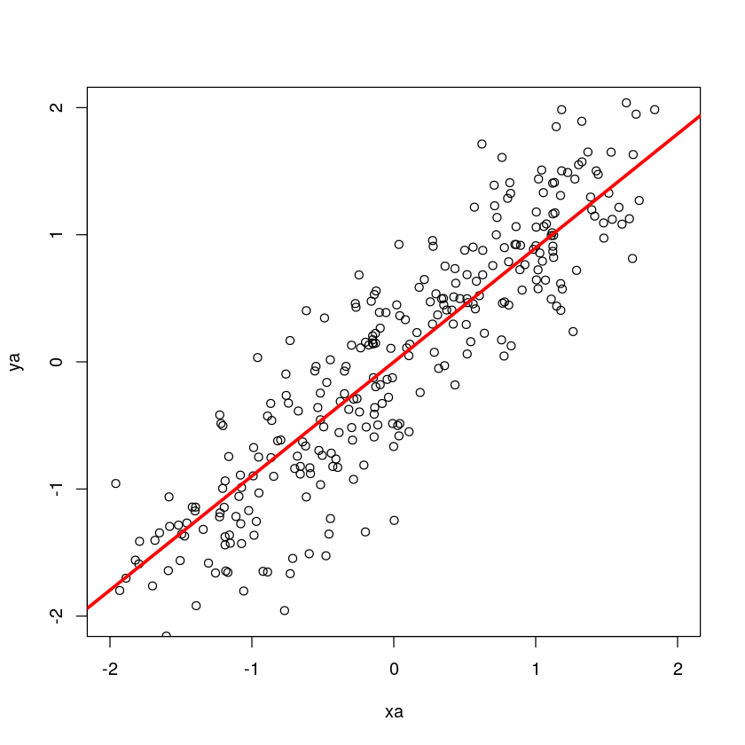

```
[1] 0.997669
```

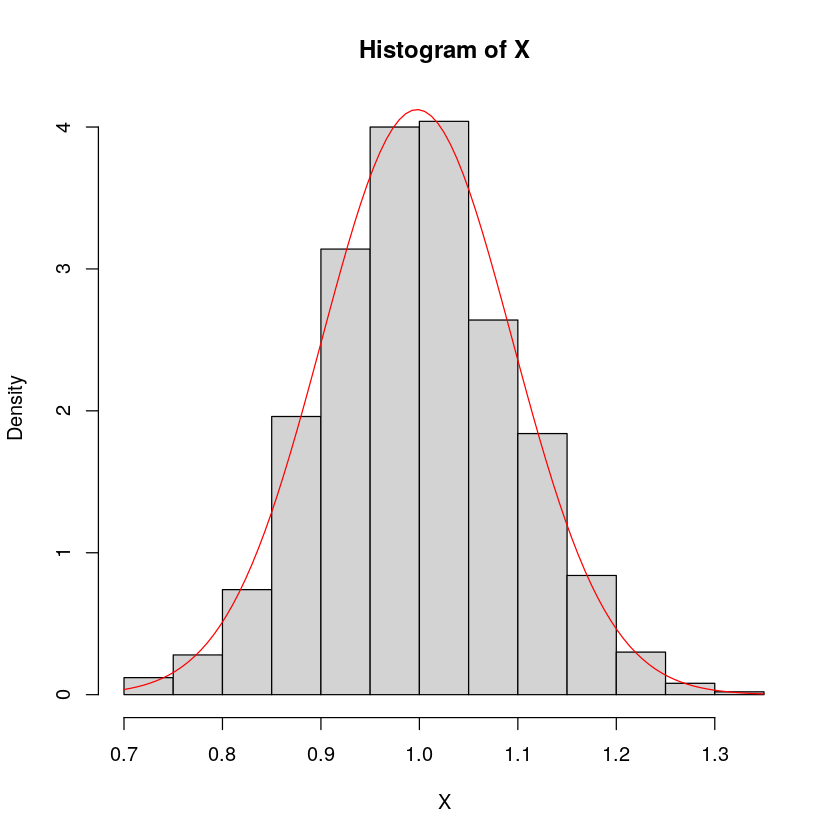

```r
steps=1000
X <- rep(NA, steps)
for (i in 1:steps) {

N=100
# x is random normal with arbitrary mean.
# y is random normal with mean x, in this way we get something like a linear function.
xa=rnorm(N, mean=-1, sd=0.5)
ya=rnorm(N, mean=xa, sd=0.5)

xb=rnorm(N, mean=0, sd=0.5)
yb=rnorm(N, mean=xb, sd=0.5)

xc=rnorm(N, mean=1, sd=0.5)
yc=rnorm(N, mean=xc, sd=0.5)


y_fit<-ya+yb+yc
x_fit<-xa+xb+xc
constant_model <- lm(y_fit ~ x_fit )
X[i]<-constant_model$coefficients[2]


}
plot(xa,ya, xlim = range(c(-2,2)) ,ylim = range(c(-2,2)) )
points(xb,yb)
points(xc,yc)
abline(constant_model, lwd = 3, col = "red")
print(constant_model$coefficients[2])
hist(X, freq=FALSE)
curve(dnorm(x,mean=mean(X),sd=sd(X)),col="red",add=T)
print(mean(X) )
```

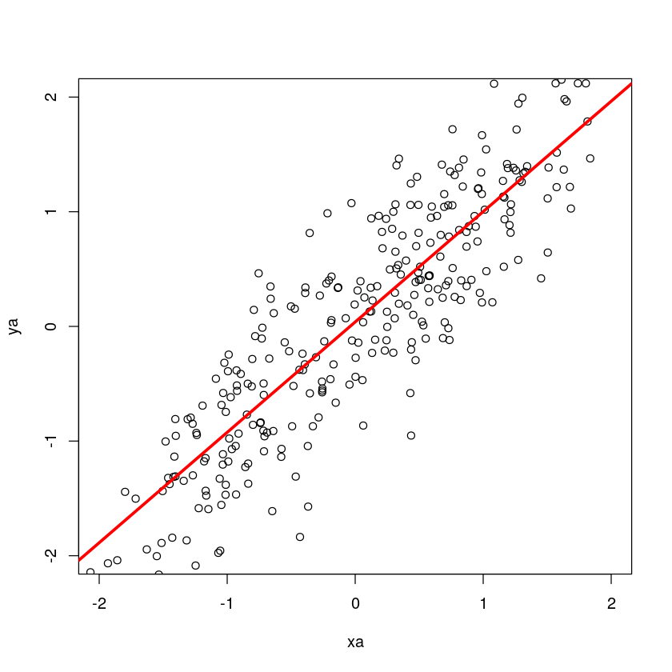

```
[1] 0.5027625
```

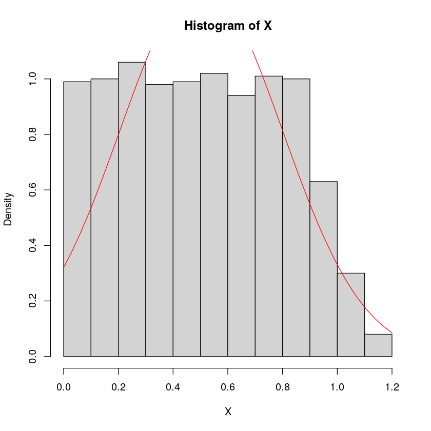

```r
#Same but now changes with each step.
steps=1000
X <- rep(NA, steps)
for (i in 1:steps) {

N=100
xa=rnorm(N, mean=-1, sd=0.5)
ya=rnorm(N, mean=xa, sd=0.5)*i/1000

xb=rnorm(N, mean=0, sd=0.5)
yb=rnorm(N, mean=xb, sd=0.5)*i/1000

xc=rnorm(N, mean=1, sd=0.5)
yc=rnorm(N, mean=xc, sd=0.5)*i/1000


y_fit<-ya+yb+yc
x_fit<-xa+xb+xc
constant_model <- lm(y_fit ~ x_fit )
X[i]<-constant_model$coefficients[2]

}
plot(xa,ya, xlim = range(c(-2,2)) ,ylim = range(c(-2,2)) )
points(xb,yb)
points(xc,yc)
abline(constant_model, lwd = 3, col = "red")
hist(X, freq=FALSE)
curve(dnorm(x,mean=mean(X),sd=sd(X)),col="red",add=T)
print(mean(X) )
```

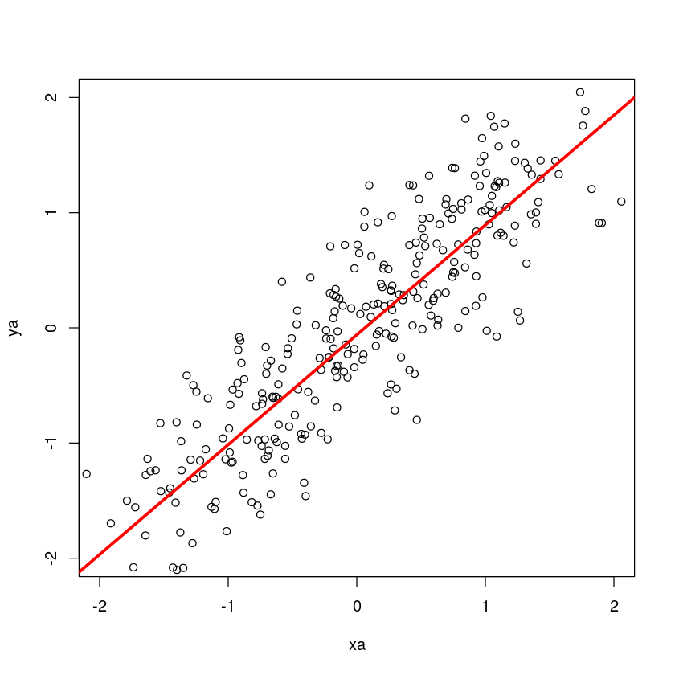

```
[1] 0.6687666
```

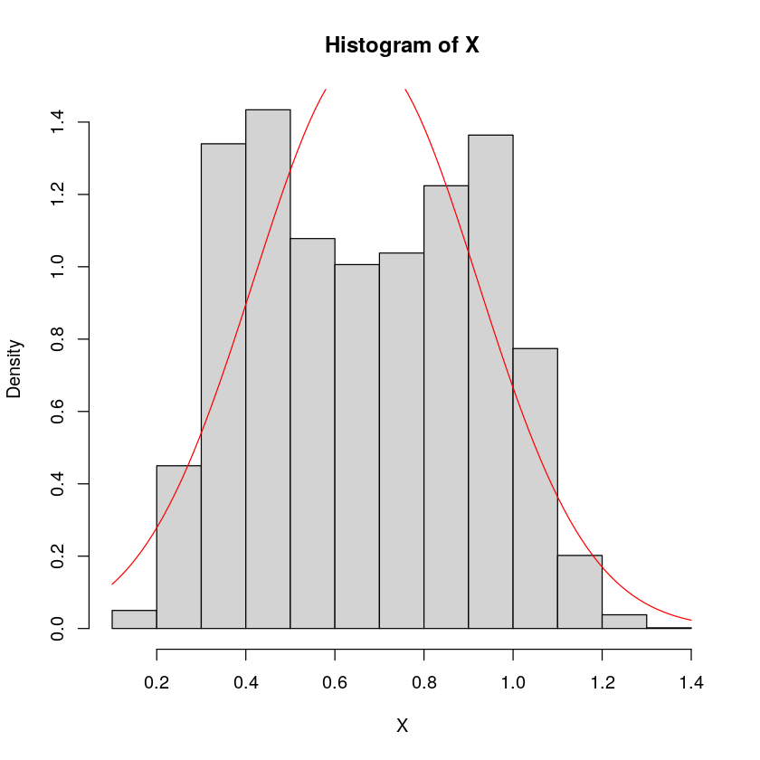

```r
#Another variation
steps=5000
X <- rep(NA, steps)
for (i in 1:steps) {

N=100
xa=rnorm(N, mean=-1, sd=0.5)
ya=rnorm(N, mean=xa, sd=0.5)*sin(i)*sin(i)

xb=rnorm(N, mean=0, sd=0.5)
yb=rnorm(N, mean=xb, sd=0.5)

xc=rnorm(N, mean=1, sd=0.5)
yc=rnorm(N, mean=xc, sd=0.5)*sin(i)*sin(i)


y_fit<-ya+yb+yc
x_fit<-xa+xb+xc
constant_model <- lm(y_fit ~ x_fit )
X[i]<-constant_model$coefficients[2]

}
plot(xa,ya, xlim = range(c(-2,2)) ,ylim = range(c(-2,2)) )
points(xb,yb)
points(xc,yc)
abline(constant_model, lwd = 3, col = "red")
#print(X)
hist(X, freq=FALSE)
curve(dnorm(x,mean=mean(X),sd=sd(X)),col="red",add=T)
print(mean(X) )
```

```
    x_fit
0.9722436
```

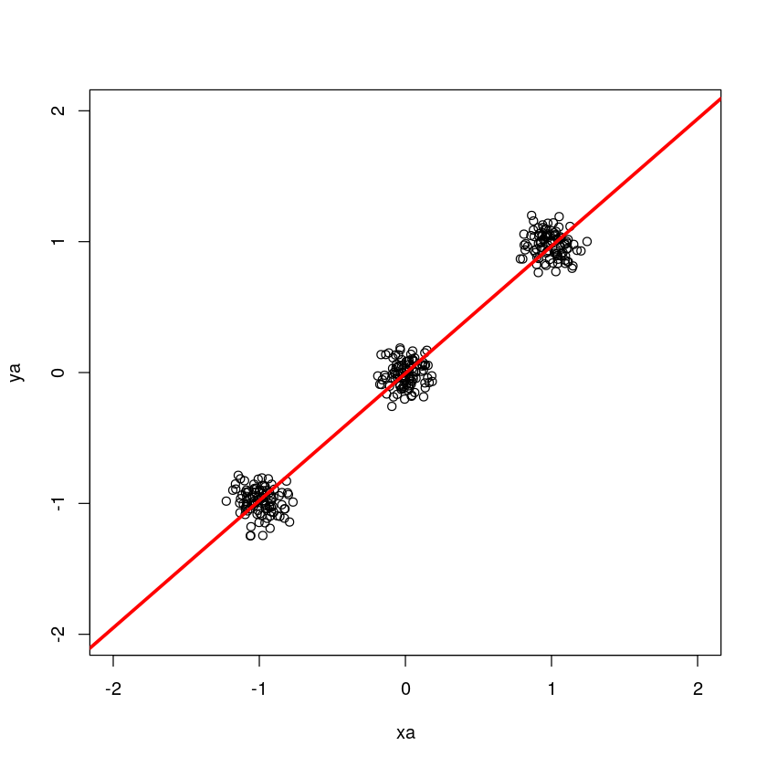

```
[1] 0.9852587
```

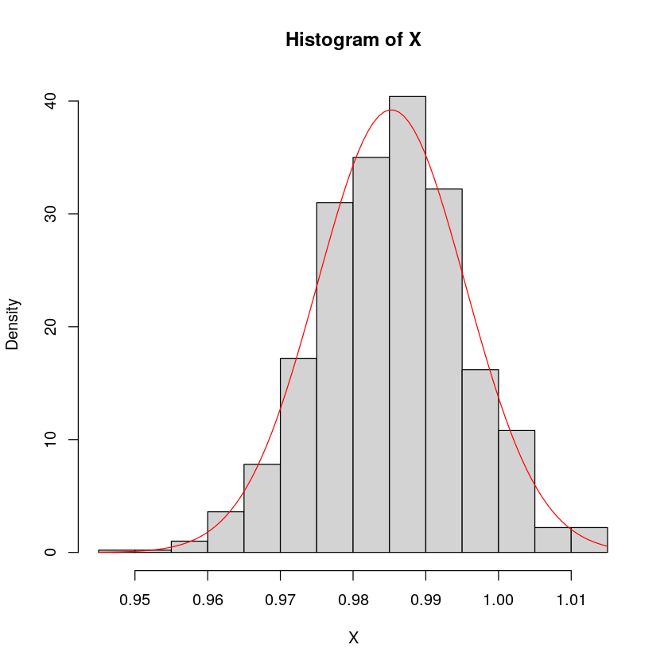

```r
### This is Gaussian in both x and y in 3 different points
# Here the linearity is forced by carefully choosing the mean in ya,yb,yc.

steps=1000
X <- rep(NA, steps)
for (i in 1:steps) {

N=100
xa=rnorm(N, mean=-1, sd=0.1)
ya=rnorm(N, mean=-1, sd=0.1)

xb=rnorm(N, mean=0, sd=0.1)
yb=rnorm(N, mean=0, sd=0.1)

xc=rnorm(N, mean=1, sd=0.1)
yc=rnorm(N, mean=1, sd=0.1)

x_fit=c(xa,xb,xc)
y_fit=c(ya,yb,yc)

constant_model <- lm(y_fit ~ x_fit)
summary(constant_model)

X[i]<-constant_model$coefficients[2]

}

plot(xa,ya, xlim = range(c(-2,2)) ,ylim = range(c(-2,2)) )
points(xb,yb)
points(xc,yc)

abline(constant_model, lwd = 3, col = "red")
print(constant_model$coefficients[2])


hist(X, freq=FALSE)
curve(dnorm(x,mean=mean(X),sd=sd(X)),col="red",add=T)
print(mean(X) )
```

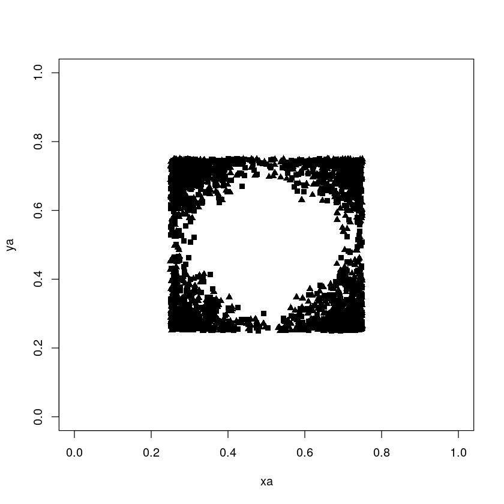

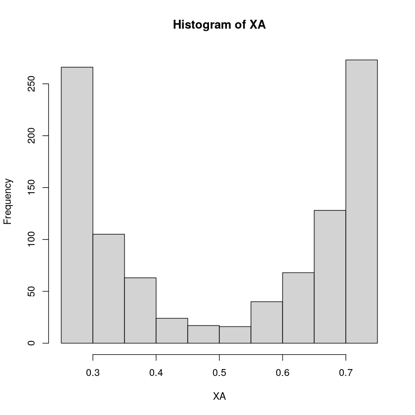

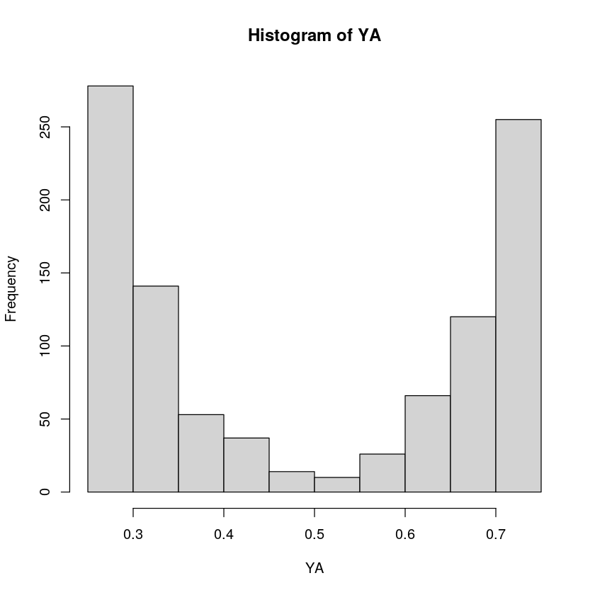

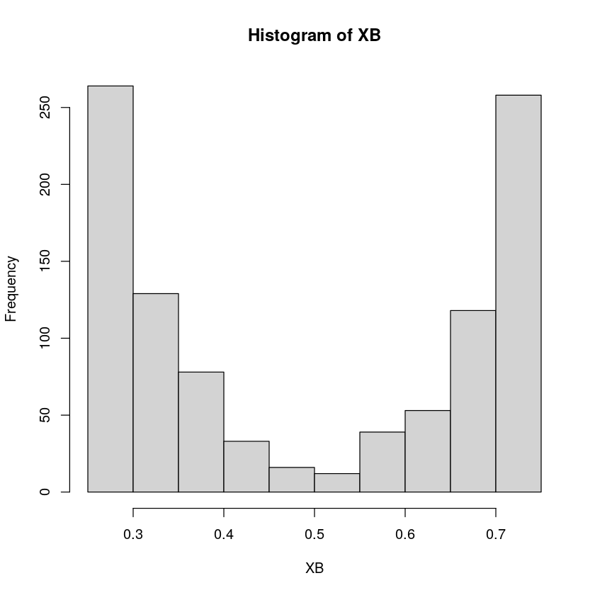

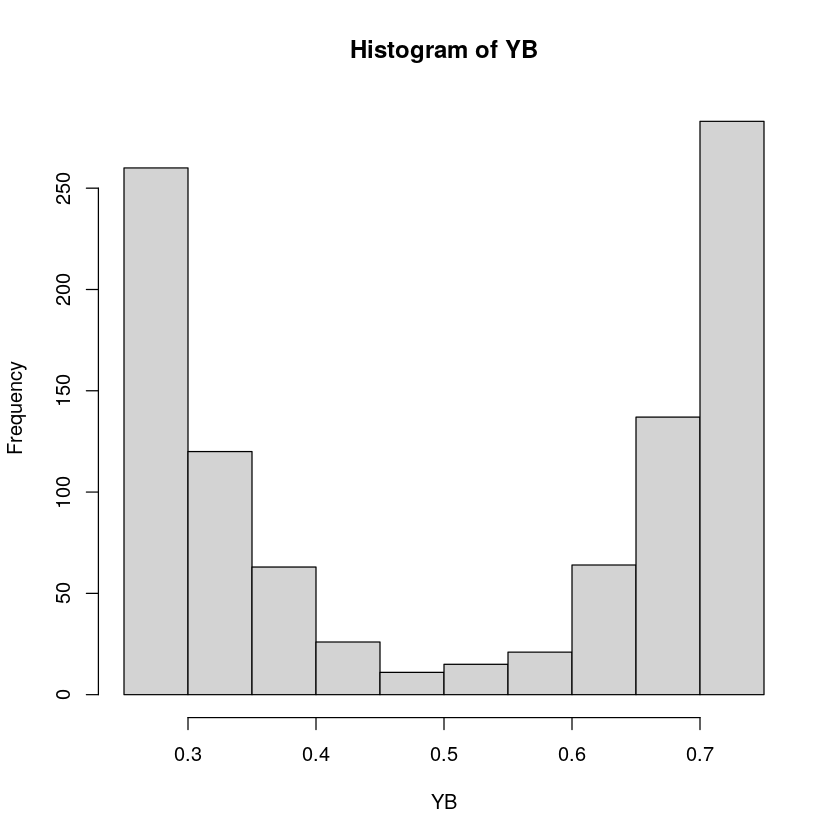

```r
### Creating 2 random disks of radii R inside a square of side L several times, just filling the space.

L=1 #square side
R=0.25  #circles radii #The limit for square of side 1 would be R=0.585786/2. Ref:https://mathworld.wolfram.com/CirclePacking.html. Beware, if you get close to the limit, the code will be slow.

xa=NA
ya=NA
plot(xa,ya, xlim = range(c(0,L)) ,ylim = range(c(0,L)))
steps=1000

XA <- rep(NA, steps)
YA <- rep(NA, steps)
XB <- rep(NA, steps)
YB <- rep(NA, steps)
for (i in 1:steps)
  {

    #First disk
    xa=runif(1,R,L-R)
    ya=runif(1,R,L-R)

    #Second disk
    xb=runif(1,R,L-R)
    yb=runif(1,R,L-R)

    #We want both disks to be more than 2 times R apart. If this is not true, we keep generating random positions.
    while ( sqrt( (xa - xb)^2 + (ya - yb)^2 ) < 2*R ) {
    xa=runif(1,R,L-R)
    ya=runif(1,R,L-R)
    xb=runif(1,R,L-R)
    yb=runif(1,R,L-R)
    }

    XA[i]=xa
    YA[i]=ya
    XB[i]=xb
    YB[i]=yb
    #Plotting
    points(xa,ya, xlim = range(c(0,L)) ,ylim = range(c(0,L)), pch = 17 )
    points(xb,yb, pch = 15 )
  }

hist(XA)
hist(YA)
hist(XB)
hist(YB)
```

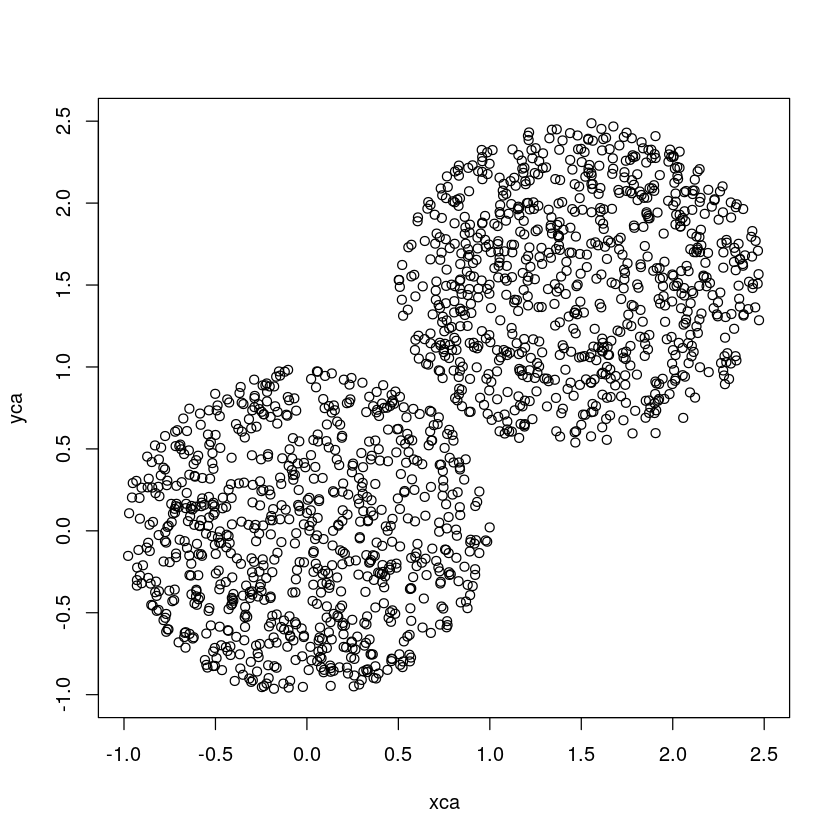

```
[1] 2.242205
```

'mean distance by algorithm 2.24220547859484'

'expected distance 2.12132034355964'

'error is 0.0569857991520277'

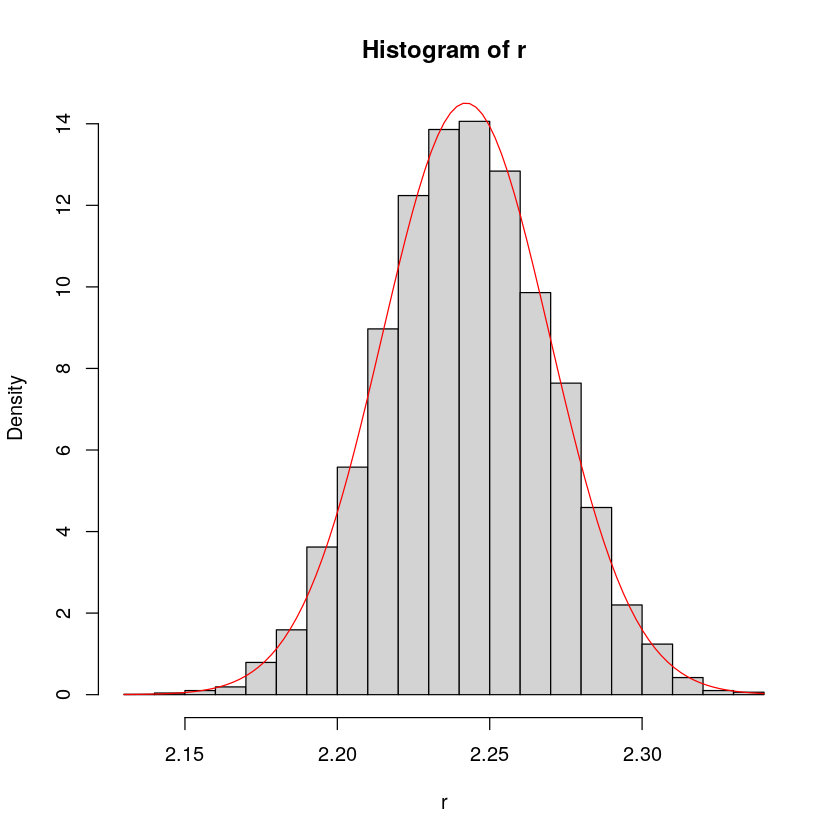

```r
#Random points cointained in two disks of same radii. The positions of disks can be changed.
##Distances between random points in the disks are calculated.
##The further away the disks are, the mean of these distances approximate the true distance.

steps=10000
r <- rep(NA, steps)
for (i in 1:steps) {

N=1000
R=1
cxa=0
cya=0
cxb=1.5
cyb=1.5

xa=runif(N,-R+cxa,R+cxa)
ya=runif(N,-R+cya,R+cya)
xb=runif(N,-R+cxb,R+cxb)
yb=runif(N,-R+cyb,R+cyb)


xca = ifelse( sqrt( (xa-cxa)^2 + (ya-cya)^2 ) > R, NA, xa)
yca = ifelse( sqrt( (xa-cxa)^2 + (ya-cya)^2 ) > R, NA, ya)
xcb = ifelse( sqrt( (xb-cxb)^2 + (yb-cyb)^2 ) > R, NA, xb)
ycb = ifelse( sqrt( (xb-cxb)^2 + (yb-cyb)^2 ) > R, NA, yb)

distance=sqrt( (xca - xcb)^2 + (yca - ycb)^2)
r[i]=mean(distance, na.rm = TRUE)

}

low=min(xa,xb,ya,yb)
high=max(xa,xb,ya,yb)

plot(xca,yca,xlim = range(c(low,high)) ,ylim = range(c(low,high))  )
points(xcb,ycb)

hist(r, freq=FALSE)
curve(dnorm(x,mean=mean(r),sd=sd(r)),col="red",add=T)
print(mean(r) )


expected=sqrt( (cxa-cxb)^2 + (cya-cyb)^2 )
paste("mean distance by algorithm",mean(r) )
paste("expected distance",expected)
error=( mean(r)-expected)/expected
paste("error is",error)
```

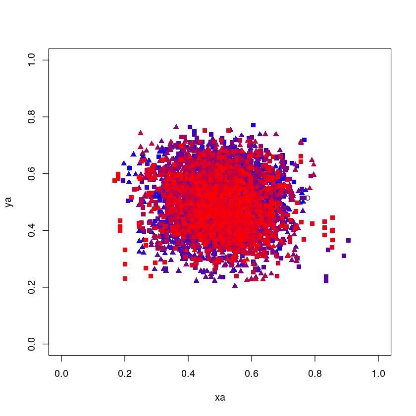

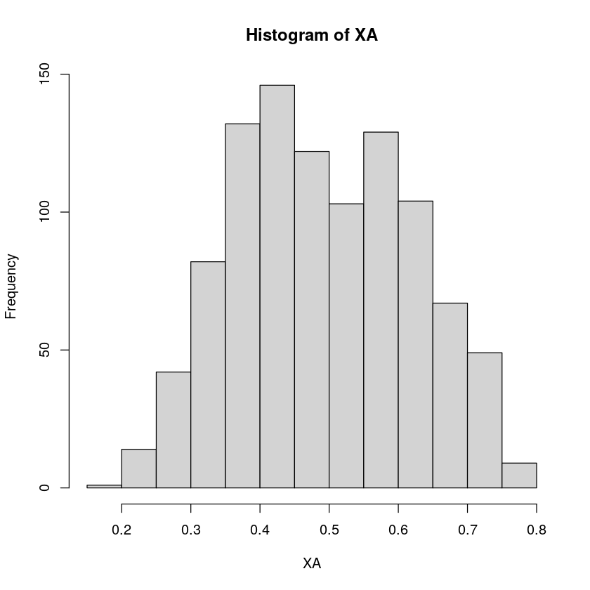

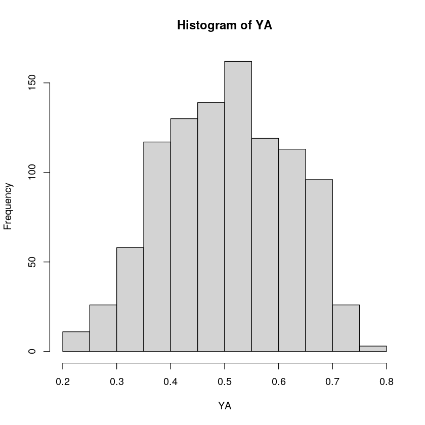

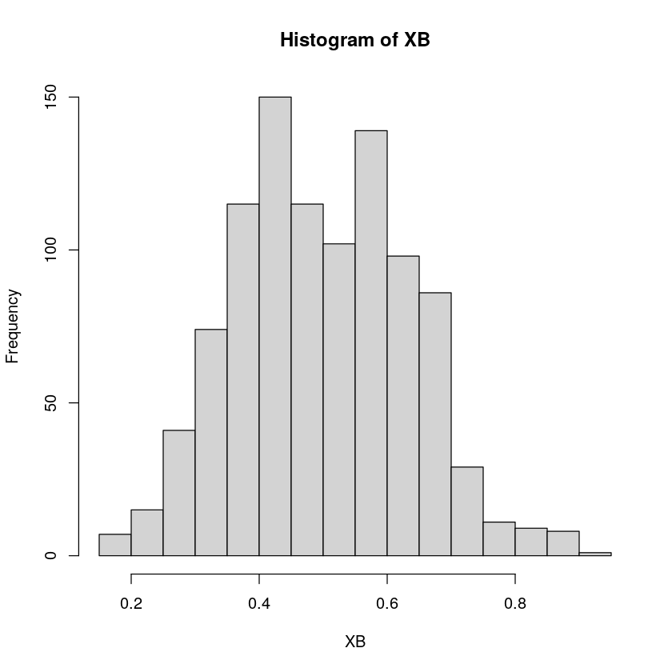

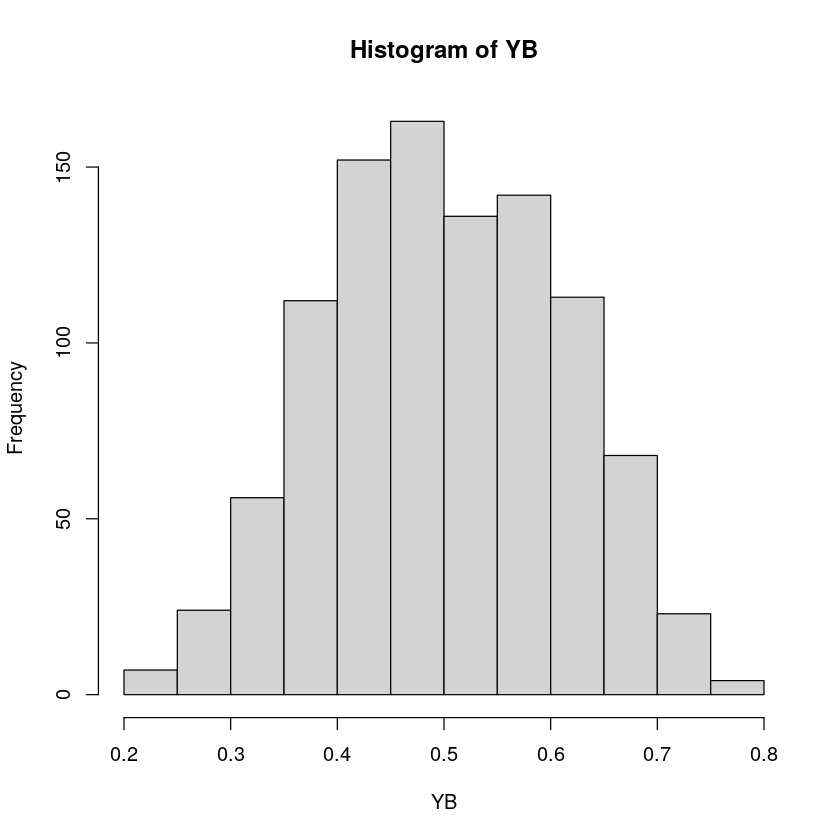

```r
### Creating 2 random disks of radii R inside a square of side L. These disk seek the center through normal dist.

L=1 #square side
R=0.1  #circles radii

#Uniform random number, from R to L-R
ran<-function(){runif(1,R,L-R)}

#Uniform random number, from -R to +R
delran<-function(){runif(1,-R,R)}

#First disk
xa=ran()
ya=ran()

#Second disk
xb=ran()
yb=ran()

#We want both disks to be more than 2 times R apart. If this is not true, we keep generating random positions.
while ( sqrt( (xa - xb)^2 + (ya - yb)^2 ) < 2*R ) {
    xb=ran()
    yb=ran()
}

#Plotting
plot(xa,ya, xlim = range(c(0,L)) ,ylim = range(c(0,L)))
points(xb,yb)

###From here on, Metropolis Algorithm


del=1


normal_prob<-function(x){dnorm(x, mean = L/2, sd = 0.1, log = FALSE)}
#normal_prob(L/2)



steps=1000
XA <- rep(NA, steps)
YA <- rep(NA, steps)
XB <- rep(NA, steps)
YB <- rep(NA, steps)

for (i in 1:steps)
  {
    xa_temp=xa
    ya_temp=ya
    xb_temp=xa #This is to make sure, a while bellow works from the first step.
    yb_temp=ya
    while ( sqrt( (xa_temp - xb_temp)^2 + (ya_temp - yb_temp)^2 ) < 2*R ) {
    xa_walk<-xa+del*delran()
    ya_walk<-ya+del*delran()
    xb_walk<-xb+del*delran()
    yb_walk<-yb+del*delran()

    U=runif(1,0,1)

    xa_temp=ifelse(U<normal_prob(xa_walk)/normal_prob(xa),xa_walk,xa)
    ya_temp=ifelse(U<normal_prob(ya_walk)/normal_prob(ya),ya_walk,ya)
    xb_temp=ifelse(U<normal_prob(xb_walk)/normal_prob(xb),xb_walk,xb)
    yb_temp=ifelse(U<normal_prob(yb_walk)/normal_prob(yb),yb_walk,yb)

    xa=xa_temp
    ya=ya_temp
    xb=xb_temp
    yb=yb_temp
    XA[i]=xa
    YA[i]=ya
    XB[i]=xb
    YB[i]=yb
    points(xa,ya, col= rgb(i/steps, 0, 1-i/steps), pch = 17 )
    points(xb,yb, col= rgb(i/steps, 0, 1-i/steps), pch = 15 )
    #print(xa)
    }

  }

hist(XA)
hist(YA)
hist(XB)
hist(YB)
```